# Genome Complexity Practical

Sara Valdimarsdottir

2025-06-08

## Overview

The purpose of this document is to showcase a simple bioinformatics inspired analysis. The analysis was inspired by a [notebook found on Kaggle](https://www.kaggle.com/code/camnugent/visualizing-size-and-gc-content-of-genomes) created by Cam Nugent in 2018. The notebook details a visual exploration of the size and GC content of sequenced genomes available on NCBI at the time. This document will recreate a modified version of the analysis, ultimately generating a modified visualization of the data highlighting how genome complexity and size varies signficantly across certain domains of life.

## Data Prep

To start, we’ll rely on only the base R functions and tidyverse library in R. Adding tidyverse to our session will allow us to efficiently manipulate the NCBI data downloaded from kaggle using packages like dplyr and ggplot.

With tidyverse loaded, let’s load in the three csv files downloaded from the kaggle repo:

```r
raw_eukaryote <- read.csv("eukaryotes.csv")
raw_prokaryote <- read.csv("prokaryotes.csv")
raw_virus <- read.csv("viruses.csv")
```

Instead of working with three seperate dataframes, let’s see if we can’t consolidate things into a single dataframe object:

```r
table(colnames(raw_eukaryote) == colnames(raw_prokaryote)) #all 16 columns have the same name and thus same info
```

```
##
## TRUE
##   16
```

```r
merged_dataframe <- rbind(raw_eukaryote, raw_prokaryote) #merge into a single dataframe
```

The viruses dataframe has unique colnames and is misordered. Since we primarily care about genome size, CDS, and the domain of life to which a sequenced organism belongs, let’s drop the extra columns and merge the virus dataframe into the previous merged_dataframe.

```r
matching_colnames <- intersect(colnames(merged_dataframe), colnames(raw_virus)) #identify colnames present across datasets
sub_raw_virus <- raw_virus[,matching_colnames] #subset the relevant cols from virus dataset
full_dataframe <- rbind(merged_dataframe[,matching_colnames], sub_raw_virus) #merge into a single dataframe
```

As noted in the original kaggle notebook, several assemblies were not quite complete at the time of data compilation - these assemblies should be ignored as they are unlikely to be accurate representation of the actual genome size/CDS contents of the sequenced genomes. We can use dplyr to subset and filter the generated dataframe as follows:

```r
full_dataframe <- full_dataframe %>% #start w/ the full_dataframe object we generated earlier
  filter(Level != "Contig" ) %>% #remove contig level assemblies
  filter(GC.>5) %>% #kaggle notebook also removed observations with less than 5% GC content
  select(-c(Replicons,GenBank.FTP,RefSeq.FTP,Release.Date)) #drop additional columns we don't need
```

Going a bit further, we can split the Organism.Groups column into three separate columns to designate the different classifications used to described the sequenced organisms:

```r
full_dataframe$Domain <- purrr::map_chr(str_split(full_dataframe$Organism.Groups, pattern = ";"),1)
full_dataframe$Kingdom <- purrr::map_chr(str_split(full_dataframe$Organism.Groups, pattern = ";"),2)
full_dataframe$Class <- purrr::map_chr(str_split(full_dataframe$Organism.Groups, pattern = ";"),3)
colnames(full_dataframe)[1] <- "Organism_Name" #fix colname

#also clean up the workspace a bit
remove(merged_dataframe,raw_eukaryote,raw_prokaryote,raw_virus, sub_raw_virus, matching_colnames)
gc()
```

```
##           used (Mb) gc trigger  (Mb) max used  (Mb)
## Ncells 1059323 56.6    2509498 134.1  2509498 134.1
## Vcells 2187479 16.7    8388608  64.0  4776689  36.5
```

## Replcating the Original Visualization

Now that we have the data formatted neatly, let’s modify the code on Kaggle and replicate the next to last figure in the notebook:

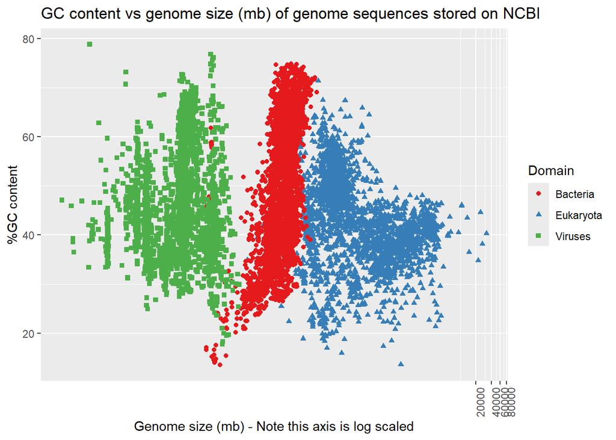

```r
ggplot(full_dataframe, aes(x=Size.Mb., y=GC., shape=Domain, colour=Domain)) +
        geom_point() +
        scale_colour_brewer(palette="Set1") +
        coord_trans(x = "log10") +
        labs(title = "GC content vs genome size (mb) of genome sequences stored on NCBI",
                y = "%GC content",
                x = "Genome size (mb) - Note this axis is log scaled") +
        theme(axis.text.x = element_text(angle = 90, hjust = 1))
```

Looks good!

What about summary statistics on GC content?

```r
full_dataframe %>% group_by(as.factor(Domain)) %>% summarise(mean=mean(GC.),median=median(GC.))
```

```
## # A tibble: 3 × 3
##   `as.factor(Domain)`  mean median
##   <fct>               <dbl>  <dbl>
## 1 Bacteria             49.4   50.6
## 2 Eukaryota            42.8   41.8
## 3 Viruses              43.2   39.5
```

Good consensus with what the [notebook reports](https://www.kaggle.com/code/camnugent/visualizing-size-and-gc-content-of-genomes#%GC-content---comparison-of-means-and-medians) for both mean and median values!

## A Change to the the Original Visualization

A set of histograms showing genome sizes across the different domains of life:

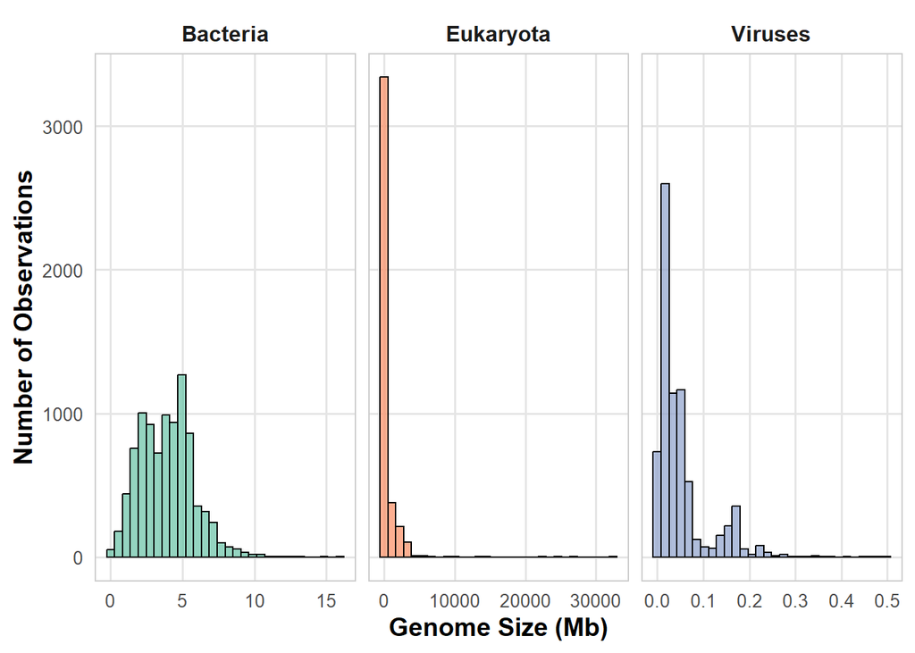

```r
ggplot(data = full_dataframe, aes(x = Size.Mb., fill = Domain)) +
  geom_histogram(color = "black", bins = 30, alpha = 0.7) +
  facet_wrap(~Domain, scales = "free_x") + #plot domains separately due to genome size differences
  xlab("Genome Size (Mb)") + #x axis name
  ylab("Number of Observations") + #y axis name
  theme_minimal(base_size = 14) + #axes font size
  theme(
    strip.text = element_text(face = "bold", size = 12), #domain font size
    axis.text = element_text(size = 10), #axes tick labels
    axis.title = element_text(face = "bold"), #make text bold
    legend.position = "none", #remove legend
    panel.grid.major = element_line(color = "grey90"),
    panel.grid.minor = element_blank(),
    panel.border = element_rect(color = "grey80", fill = NA)
  ) +
  scale_fill_brewer(palette = "Set2")
```

The figure shows us that the different domains of life have drastically different genome sizes, some orders of magnitude larger than others. To look at these genomes in one plot, it might be useful to transform the values into a logarithmic scale. Let’s plot genome sizes - on a log scale - against the GC content and see if we can’t differentiate Domains visually:

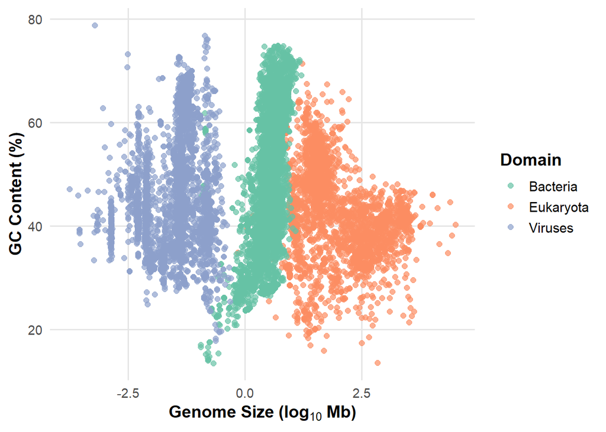

GC vs Genome Size. Note how the different domains of life can be differentiated moreso by genome size than by GC content.

```r
ggplot(data = full_dataframe, aes(x = log10(Size.Mb.), y = GC., colour = Domain)) +
  geom_point(alpha = 0.7, size = 2) +
  xlab(expression(bold("Genome Size (log"[10]*" Mb)"))) +
  ylab("GC Content (%)") +
  scale_color_brewer(palette = "Set2", name = "Domain") +
  theme_minimal(base_size = 14) +
  theme(
    axis.title.x = element_text(face = "bold"),
    axis.title.y = element_text(face = "bold"),
    axis.text = element_text(size = 11),
    legend.title = element_text(face = "bold"),
    panel.grid.major = element_line(color = "grey90"),
    panel.grid.minor = element_blank(),
    legend.position = "right"
  )
```

Now let’s plot complexity (as measured by the number of CDS annotated in a genome) as a function of genome size.

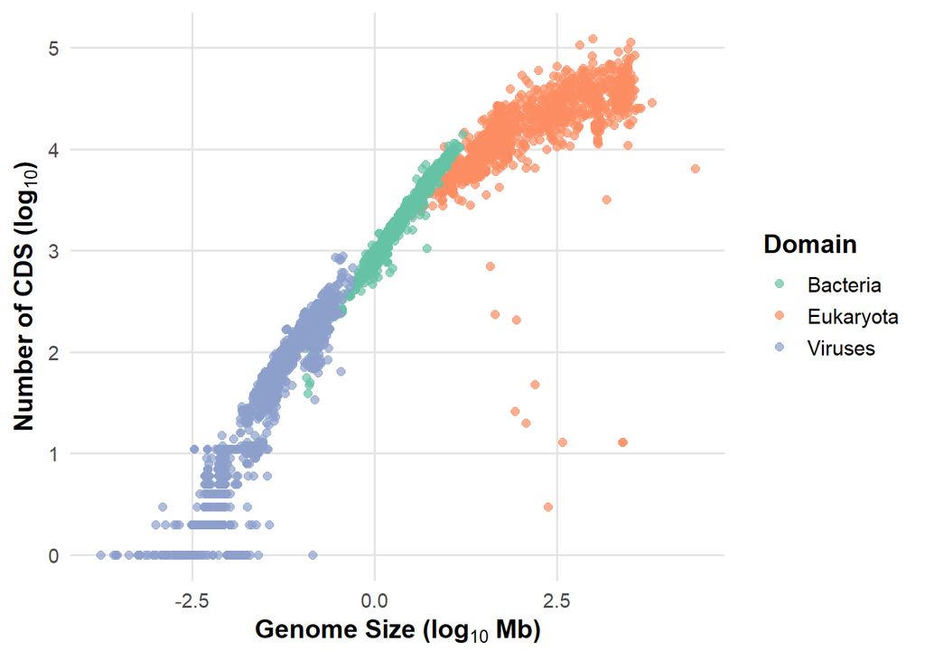

Genome Size vs CDS.

```r
ggplot(data = full_dataframe[full_dataframe$CDS != 0, ], #remove genomes where no genes were annotated
       aes(x = log10(Size.Mb.), y = log10(CDS), colour = Domain)) +
  geom_point(alpha = 0.7, size = 2) +
  xlab(expression(bold("Genome Size (log"[10]*" Mb)"))) +
  ylab(expression(bold("Number of CDS (log"[10]*")"))) +
  scale_color_brewer(palette = "Set2", name = "Domain") +
  theme_minimal(base_size = 14) +
  theme(
    axis.title = element_text(face = "bold"),
    axis.text = element_text(size = 11),
    legend.title = element_text(face = "bold"),
    panel.grid.major = element_line(color = "grey90"),
    panel.grid.minor = element_blank(),
    legend.position = "right"
  )
```

## A Simple Regression Analysis

In this final section, lets see if the number of genes a genome contains is significantly associated with the size of its genome. Further, lets also split the analysis by the different Domain categories we have.

```r
# Filter out rows where CDS is zero
filtered_data <- full_dataframe[full_dataframe$CDS != 0, ]

# Fit linear model: log10(CDS) ~ log10(Genome Size in Mb)
model <- lm(log10(CDS) ~ log10(Size.Mb.) * Domain, data = filtered_data)

# Output model summary
summary(model)
```

```
##
## Call:
## lm(formula = log10(CDS) ~ log10(Size.Mb.) * Domain, data = filtered_data)
##
## Residuals:
##     Min      1Q  Median      3Q     Max
## -3.7857 -0.0444  0.0045  0.0439  1.2939
##
## Coefficients:
##                                  Estimate Std. Error t value Pr(>|t|)
## (Intercept)                      2.950996   0.003428  860.86   <2e-16 ***
## log10(Size.Mb.)                  1.009604   0.005803  173.97   <2e-16 ***
## DomainEukaryota                  0.497240   0.009949   49.98   <2e-16 ***
## DomainViruses                    0.413091   0.006692   61.73   <2e-16 ***
## log10(Size.Mb.):DomainEukaryota -0.666448   0.007335  -90.86   <2e-16 ***
## log10(Size.Mb.):DomainViruses    0.229392   0.006856   33.46   <2e-16 ***
## ---
## Signif. codes:  0 '***' 0.001 '**' 0.01 '*' 0.05 '.' 0.1 ' ' 1
##
## Residual standard error: 0.1434 on 18212 degrees of freedom
## Multiple R-squared:  0.9838, Adjusted R-squared:  0.9838
## F-statistic: 2.209e+05 on 5 and 18212 DF,  p-value: < 2.2e-16
```

The regression analysis confirms that all domains of life share a common association: the larger your genome, the more protein coding genes you’ll likely encode. A few key observations:

- In Bacteria a doubling of genome size will approximately double the number of protein coding genes annotated (the relationship has a slope of ~1).
- In Eukaryotes, genome expansion doesn’t translate into as linear of an increase in the number of protein coding genes encoded by the organism (a smaller slope than observed in bacteria - keep in mind the log scale used in both metrics)

Let’s visualize these trends on the previous figure:

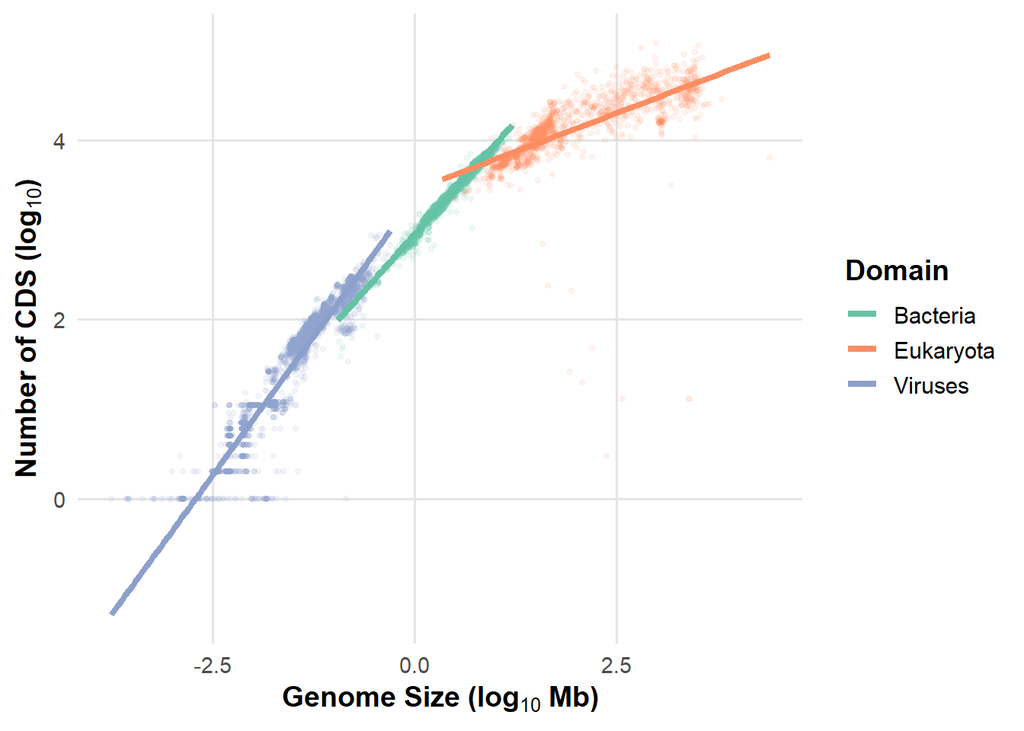

```r
ggplot(filtered_data, aes(x = log10(Size.Mb.), y = log10(CDS), colour = Domain)) +
  geom_point(alpha = 0.1, size = 1) +
  geom_smooth(method = "lm", aes(colour = Domain), se = FALSE, linewidth = 1.5) +
  xlab(expression(bold("Genome Size (log"[10]*" Mb)"))) +
  ylab(expression(bold("Number of CDS (log"[10]*")"))) +
  scale_color_brewer(palette = "Set2", name = "Domain") +
  theme_minimal(base_size = 14) +
  theme(
    axis.title = element_text(face = "bold"),
    axis.text = element_text(size = 11),
    legend.title = element_text(face = "bold"),
    panel.grid.major = element_line(color = "grey90"),
    panel.grid.minor = element_blank(),
    legend.position = "right"
  )
```

## Final Thoughts

The goal of this document was to showcase how the manipulation and visualization of computationally derived data can highlight insights about the biology of organisms.

While the notebook found on Kaggle focused on the GC content and genome size of the organisms available on NCBI - the analysis shown here replicated and then modified the original analysis. As expected, the insights visualized in this analysis are supported by published literature. Indeed, several [sources](https://www.nature.com/scitable/topicpage/eukaryotic-genome-complexity-437/) have shown that Eukaryotes have developed methods other than increased genome size to increase the variety of protein coding genes in their genomes. Alternative splicing of individual genes is one such method. More frequent and longer intron spans are also known to occur in Eukaryotes - further explaining the disconnect between larger sizes and the number of protein coding genes encoded by a a genome.

## Future Directions

Viral and bacterial genome assembly (denovo or reference guided) and comparative analyses are tasks which do not require access to extensive hardware setups. I will look into comparing denovo genome assemblers such as [SPAdes](https://github.com/ablab/spades), [MEGAHIT](https://github.com/voutcn/megahit), or [VELVET](https://github.com/dzerbino/velvet) using publicly available short read data.